# Assessing variability and association of rice agronomic traits across subpopulations and regions

Uzezi Okinedo

11/27/2020

# Introduction

Over half of the world’s population depend on rice for survival as it serves as a major staple food for an estimated 66% of people in almost all regions. Therefore, increased rice production will play a crucial role in improving food security, eradicating poverty and supplementing energy demands as it currently provides over 20% of energy. Predictions have shown that when compared with 1995, 60% more rice will have to be produced by 2030 (Saleh et al., 2020).

Influenced by quantitative trait loci (QTL) genes and environmental factors, yield is one of the most significant and complex trait in rice. In rice species, yield is determined by certain factors, classified as either direct or indirect. Direct determinants of yield include 1000 or 100 – grain weight depending on the size of the grain, filled grains per panicle and panicle number per unit area and/or per plant, while indirect determinants include traits like plant height, growth period, tillering ability, panicle length, seed length, seed setting rate, and grains per panicle (Li et al., 2019).

One major predictor of milling yield is test weight, a component used for the comparison of grain densities and it is derived by weighing a known grain volume. It is dependent on embryo size and reserved nutrient quantity which is used for germination and growth. Lower test weight scores occur due to unfavorable field environmental conditions or poor grain filling prior to harvest. Depending on grain size, the 100 or 1000 grain weight is an important measure of seed quality which has a positive effect on seedling growth, seed potential, sprouting and overall plant performance (Deivasigamani S & Swaminathan C, 2018).

Over the years, studies have focused on overall rice yield prediction using agronomic traits (Miedaner et al., 2019; Prakash Poudel, 2018; Puji Lestari et al., 2015; Venkateswarlu et al., n.d.), where test weight has been the leading determinant of grain yield. However, the realization of yield potential which is measured by multiplying the number of spikelets per unit area by average grain weight is highly dependent on some latent factors (Venkateswarlu et al., n.d.). Considering the strong association between test weight and increased yield potential, it will be relatively important to explore factors that might influence or control test weight in rice cultivars. Therefore, this study seeks to;

1. Explore trait variation across subpopulations and regions.
2. Examine the extent of association between test weight (100 seed weight) and yield attributing traits across rice subpopulations and geographical regions.
3. Identify direct and latent factors influencing test weight across subpopulations.

# Materials and Methods

**Rice Diversity Panel 1 Dataset**

The RDP1 (Reg. No. MP-6, NSL 500357 MAP) dataset is used in this study [here](https://www.ars.usda.gov/ARSUserFiles/60280500/RDP1/RDP1_JPR%20pheno%20and%20marker%20data%20for%20submission%20to%20GSOR-GRIN_v6_R2_08042016.xlsx). It broadly represents the wide range of phenotypic and genotypic variation within *O. sativa*. It consists of 421 purified homozygous rice (Oryza sativa L.) accessions (GSOR 301001 through GSOR 301421; GSOR 312001 through 312020) which include both landraces and elite rice cultivars. Accessions are classified into five subpopulation groups namely; indica (95 accessions) and aus (60), which belong to the Indica varietal group, and tropical japonica (106), temperate japonica (111), and aromatic (Group V) (16) which comprise the Japonica varietal group. Thirty-three accessions shared <60% ancestry with a single group and were classified as admixtures (Eizenga et al., 2014). Data can be downloaded here (usda.gov). The data selected for the analysis included the following trait data; 100 seed weight (HHGW), panicle number per unit area (PNN), filled grain number per panicle (FGN), plant height (PTH), panicle length (PNL), total florets per panicle (FLN).

**Statistical Analysis**

All statistical analysis were carried out in R version 4.0.2. Data was loaded into R studio and all missing values and unknown groups were filtered out. For descriptive statistics, boxplots were plotted using the ‘ggplot2’ package to show the distribution of traits across all regions and subpopulations. Before inferential statistical analysis were performed, data was preprocessed and normalized using the caret package after which density plots were drawn to visualize normality. PCA analysis was performed using the ‘ggbiplot’ package. Standardized major axis (SMA) slopes were used for the summary of bivariate trait relationships and to test whether the regression of test weight and other agronomic traits differed among subpopulations and regions. SMA regression was carried out using the ‘smart’ package. Multivariate causal network for all selected traits was quantified with a Structural Equation Model (SEM) using the ‘lavaan’ package. SEM combines multiple regression analysis and factor analysis for the evaluation of structural relationships, estimating interrelated dependence in a single analysis (Li et al., 2019; Regression & Models, 2005). A general linear regression was performed, where the most correlated variable, FLN was used as predictor for test weight across subpopulation and region. All relevant assumptions were tested and post hoc analyses were carried out.

# Analysis and Results

```r
# load all required libraries
library(tidyverse)
library(smatr)
library(Cairo)
library(extrafont)
library(clusterSim)
library(caret)
library(grid)
library(gridExtra)
library(scales)
library(ggpubr)
library(lavaan)
```

```r
library(semPlot)
library(devtools)
library(multcomp)
library(car)
library(emmeans)
library(modelr)
#library(ggbiplot)
library(kableExtra)
```

**Distribution of subpopulations across regions**

```r
# load data and clean names
rice <- read.csv("./raw_data/rice_phenotype_data.csv") %>%
  janitor::clean_names() %>%
  filter(!subpopulation_group_pca %in% "N/A") %>%
  filter(!region %in% "Unknown") %>%
  na.omit()

# view data
head(rice)
```

```
##   nsftv_id gsor_id irgc_id          name orignal_providing_country
## 1        1  301001  126380      Agostano                     Italy
## 2        3  301003  117636 Ai-Chiao-Hong                     China
## 3        6  301006  117603      ARC 7229                     India
## 4        7  301007  126381         Arias                 Indonesia
## 5        8  301008  117643   Asse Y Pung               Philippines
## 6        9  301009  117647         Baber                     India
##           region subpopulation_group_structure subpopulation_group_pca
## 1    West Europe                           TEJ                     TEJ
## 2      East Asia                           IND                     IND
## 3     South Asia                           AUS                     AUS
## 4 Southeast Asia                           TRJ                     TRJ
## 5 Southeast Asia                           TRJ                     TRJ
## 6     South Asia                       ADMIX_J                     TEJ
##   subpopulation_group_fast_structure amycn alkdig dhulprotcn  dthd  ptht flflg
```

[output cut: 27 more lines]

```r
# check data structure
str(rice)
```

```
## 'data.frame':    383 obs. of  38 variables:
##  $ nsftv_id                          : chr  "1" "3" "6" "7" ...
##  $ gsor_id                           : chr  "301001" "301003" "301006" "301007" ...
##  $ irgc_id                           : chr  "126380" "117636" "117603" "126381" ...
##  $ name                              : chr  "Agostano" "Ai-Chiao-Hong" "ARC 7229" "Arias" ...
##  $ orignal_providing_country         : chr  "Italy" "China" "India" "Indonesia" ...
##  $ region                            : chr  "West Europe" "East Asia" "South Asia" "Southeast Asia" ...
##  $ subpopulation_group_structure     : chr  "TEJ" "IND" "AUS" "TRJ" ...
##  $ subpopulation_group_pca           : chr  "TEJ" "IND" "AUS" "TRJ" ...
##  $ subpopulation_group_fast_structure: chr  "temperate-japonica" "indica" "aus" "tropical-japonica" ...
##  $ amycn                             : chr  "15.6" "23.1" "23.2" "20.1" ...
##  $ alkdig                            : chr  "6.1" "5.8" "5.5" "6.3" ...
##  $ dhulprotcn                        : chr  "8.4" "9.2" "8.5" "11.8" ...
##  $ dthd                              : chr  "75.1" "89.5" "89.1" "105" ...
##  $ ptht                              : chr  "110.9" "143.5" "148.3" "119.6" ...
```

[output cut: 26 more lines]

```r
# convert characters to class numeric
rice2 <- rice %>%
  mutate(hhulgrwt1 = as.numeric(hhulgrwt),
         hulgrvol1 = as.numeric(hulgrvol),
         ptht1 = as.numeric(ptht),
         pnlg1 = as.numeric(pnlg),
         pnnb1 = as.numeric(pnnb),
         dthd1 = as.numeric(dthd),
         filgrnb1 = as.numeric(filgrnb),
         flnbppn1 = as.numeric(flnbppn))

# str data
str(rice2)
```

```
## 'data.frame':    383 obs. of  46 variables:
##  $ nsftv_id                          : chr  "1" "3" "6" "7" ...
##  $ gsor_id                           : chr  "301001" "301003" "301006" "301007" ...
##  $ irgc_id                           : chr  "126380" "117636" "117603" "126381" ...
##  $ name                              : chr  "Agostano" "Ai-Chiao-Hong" "ARC 7229" "Arias" ...
##  $ orignal_providing_country         : chr  "Italy" "China" "India" "Indonesia" ...
##  $ region                            : chr  "West Europe" "East Asia" "South Asia" "Southeast Asia" ...
##  $ subpopulation_group_structure     : chr  "TEJ" "IND" "AUS" "TRJ" ...
##  $ subpopulation_group_pca           : chr  "TEJ" "IND" "AUS" "TRJ" ...
##  $ subpopulation_group_fast_structure: chr  "temperate-japonica" "indica" "aus" "tropical-japonica" ...
##  $ amycn                             : chr  "15.6" "23.1" "23.2" "20.1" ...
##  $ alkdig                            : chr  "6.1" "5.8" "5.5" "6.3" ...
##  $ dhulprotcn                        : chr  "8.4" "9.2" "8.5" "11.8" ...
##  $ dthd                              : chr  "75.1" "89.5" "89.1" "105" ...
##  $ ptht                              : chr  "110.9" "143.5" "148.3" "119.6" ...
```

[output cut: 34 more lines]

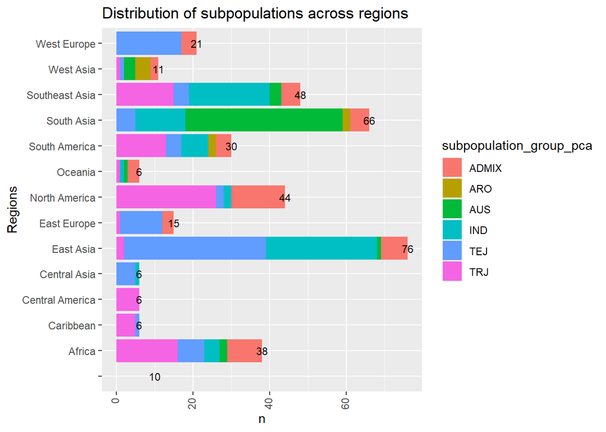

```r
# Distribution of subpopulations across all regions

# create an object for total region counts
totals <- rice2 %>%
  count(region)

# create a barplot object
barplot <- rice2 %>%
  count(subpopulation_group_pca, region) %>%
  filter(n !=10) %>%
  ggplot(aes(y = region, x = n)) +
  geom_bar(stat = "identity", aes(fill = subpopulation_group_pca)) +
  theme(axis.text.x = element_text(angle = 90, vjust=0.3, hjust=1)) +
  geom_text(data = totals, aes(label = n), cex = 3) +
  labs(y ="Regions", title = "Distribution of subpopulations across regions")

# visulaize barplot
barplot
```

**Trait differences across regions and sub-populations**

```
## $`1`
```

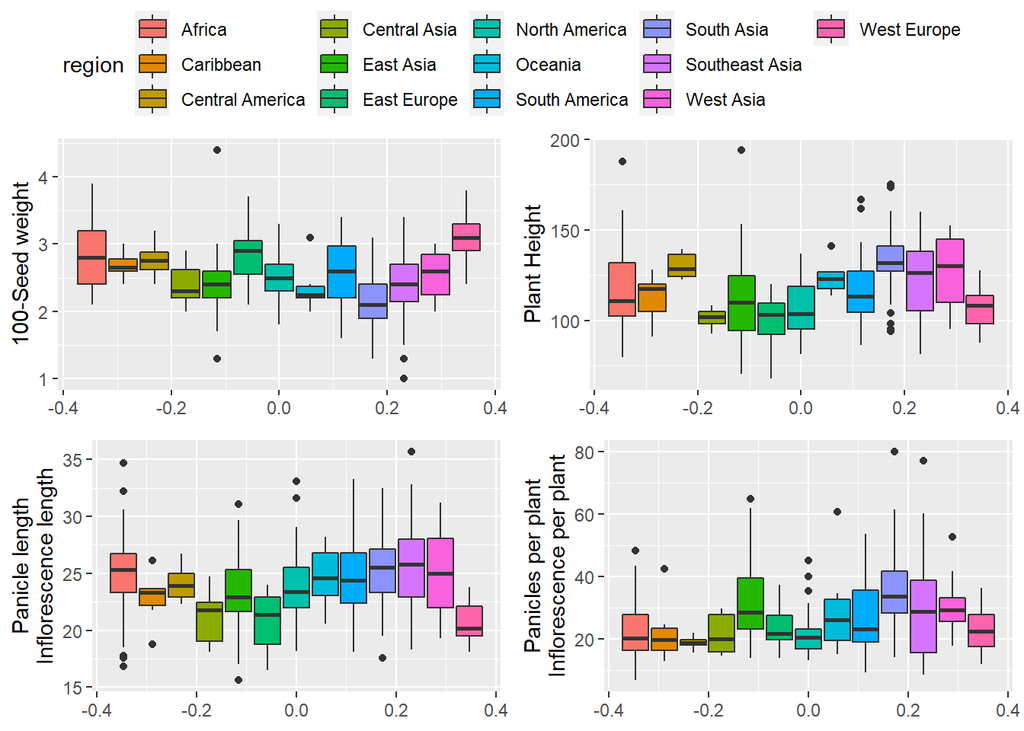

```
##
## $`2`
```

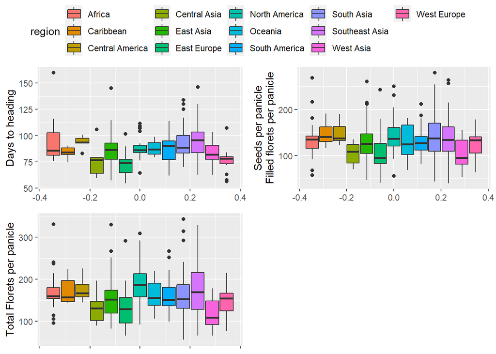

```
##
## attr(,"class")
## [1] "list"      "ggarrange"
```

```r
# trait differences across regions and across sub-populations
hhulgrwt <- ggplot(rice2,
       aes(y = hhulgrwt1, fill = region)) +
  geom_boxplot() +
  labs(y ="100-Seed weight")


ptht <- ggplot(rice2,
       aes(y = ptht1, fill = region)) +
  geom_boxplot() +
  labs(y ="Plant Height")


pnlg <- ggplot(rice2,
       aes(y = pnlg1, fill = region)) +
  geom_boxplot() +
  labs(y ="Panicle length
Inflorescence length")


pnnb <- ggplot(rice2,
       aes(y = pnnb1, fill = region)) +
  geom_boxplot() +
  labs(y ="Panicles per plant
Inflorescence per plant")


dthd <- ggplot(rice2,
       aes(y = dthd1, fill = region)) +
  geom_boxplot() +
  labs(y ="Days to heading")


filgrnb <- ggplot(rice2,
       aes(y = filgrnb1, fill = region)) +
  geom_boxplot() +
  labs(y ="Seeds per panicle
Filled florets per panicle")


flnbppn <- ggplot(rice2,
       aes(y = flnbppn1, fill = region)) +
  geom_boxplot() +
  labs(y ="Total Florets per panicle")



ggarrange(hhulgrwt, ptht, pnlg, pnnb, dthd, filgrnb, flnbppn  + rremove("x.text"), common.legend = TRUE, ncol = 2, nrow = 2)
```

```
## $`1`
```

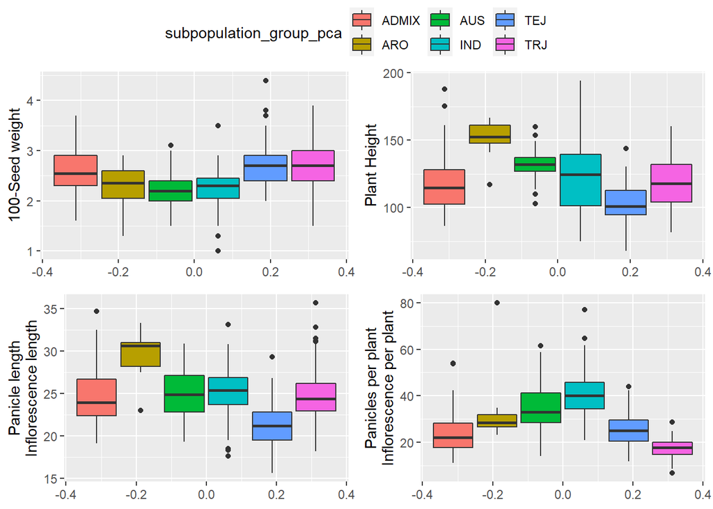

```
##
## $`2`
```

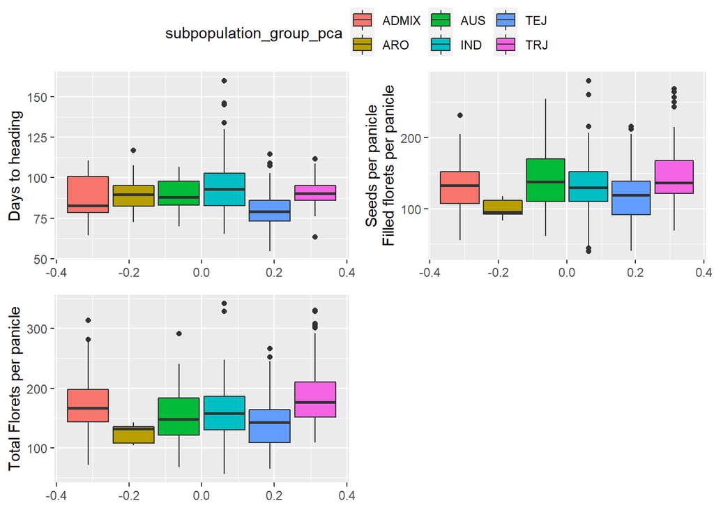

```
##
## attr(,"class")
## [1] "list"      "ggarrange"
```

```r
#------------------------------------------------------------------------------


# trait differences across subpopulations
hhulgrwt <- ggplot(rice2,
       aes(y = hhulgrwt1, fill = subpopulation_group_pca)) +
  geom_boxplot() +
  labs(y ="100-Seed weight")


ptht <- ggplot(rice2,
       aes(y = ptht1, fill = subpopulation_group_pca)) +
  geom_boxplot() +
  labs(y ="Plant Height")


pnlg <- ggplot(rice2,
       aes(y = pnlg1, fill = subpopulation_group_pca)) +
  geom_boxplot() +
  labs(y ="Panicle length
Inflorescence length")


pnnb <- ggplot(rice2,
       aes(y = pnnb1, fill = subpopulation_group_pca)) +
  geom_boxplot() +
  labs(y ="Panicles per plant
Inflorescence per plant")


dthd <- ggplot(rice2,
       aes(y = dthd1, fill = subpopulation_group_pca)) +
  geom_boxplot() +
  labs(y ="Days to heading")


filgrnb <- ggplot(rice2,
       aes(y = filgrnb1, fill = subpopulation_group_pca)) +
  geom_boxplot() +
  labs(y ="Seeds per panicle
Filled florets per panicle")


flnbppn <- ggplot(rice2,
       aes(y = flnbppn1, fill = subpopulation_group_pca)) +
  geom_boxplot() +
  labs(y ="Total Florets per panicle")


# arrange all plots side by side using ggarrange
ggarrange(hhulgrwt, ptht, pnlg, pnnb, dthd, filgrnb, flnbppn, rremove("x.text"), common.legend = TRUE, ncol = 2, nrow = 2)
```

**Data normalization for regression analysis**

```r
# scale and center data using Caret library
preproc1 <- preProcess(rice2[,39:46], method=c("center", "scale"))

# normalize data with mean 0 and standard deviation 1
norm1 <- predict(preproc1, rice2[,39:46]) %>%
  mutate(region = rice2$region,
         subpopulation =rice2$subpopulation_group_pca) %>%
  na.omit() %>%
  dplyr::rename(HHGW = hhulgrwt1,
         HGV = hulgrvol1,
         PTH = ptht1,
         PNL = pnlg1,
         PNN = pnnb1,
         DTH = dthd1,
         FGN = filgrnb1,
         FLN = flnbppn1)

# summary of normalized data
summary(norm1)
```

```
##       HHGW               HGV                PTH                 PNL
##  Min.   :-3.13283   Min.   :-1.85980   Min.   :-2.404944   Min.   :-2.46837
##  1st Qu.:-0.63691   1st Qu.:-0.69574   1st Qu.:-0.781939   1st Qu.:-0.61774
##  Median :-0.22092   Median :-0.07214   Median :-0.017243   Median :-0.04441
##  Mean   : 0.02193   Mean   : 0.01695   Mean   : 0.006418   Mean   : 0.01261
##  3rd Qu.: 0.61105   3rd Qu.: 0.64501   3rd Qu.: 0.674510   3rd Qu.: 0.63778
##  Max.   : 3.93895   Max.   : 3.17060   Max.   : 3.746671   Max.   : 3.36654
##       PNN                DTH                FGN                 FLN
##  Min.   :-1.80455   Min.   :-2.41050   Min.   :-2.293937   Min.   :-1.929527
##  1st Qu.:-0.74798   1st Qu.:-0.60661   1st Qu.:-0.626699   1st Qu.:-0.610398
##  Median :-0.22914   Median :-0.15163   Median :-0.039020   Median :-0.116219
##  Mean   :-0.02606   Mean   :-0.02416   Mean   : 0.003102   Mean   : 0.006202
##  3rd Qu.: 0.56907   3rd Qu.: 0.52461   3rd Qu.: 0.526551   3rd Qu.: 0.521558
##  Max.   : 3.07712   Max.   : 5.11907   Max.   : 3.608639   Max.   : 3.564864
##     region          subpopulation
##  Length:364         Length:364
##  Class :character   Class :character
##  Mode  :character   Mode  :character
##
##
##
```

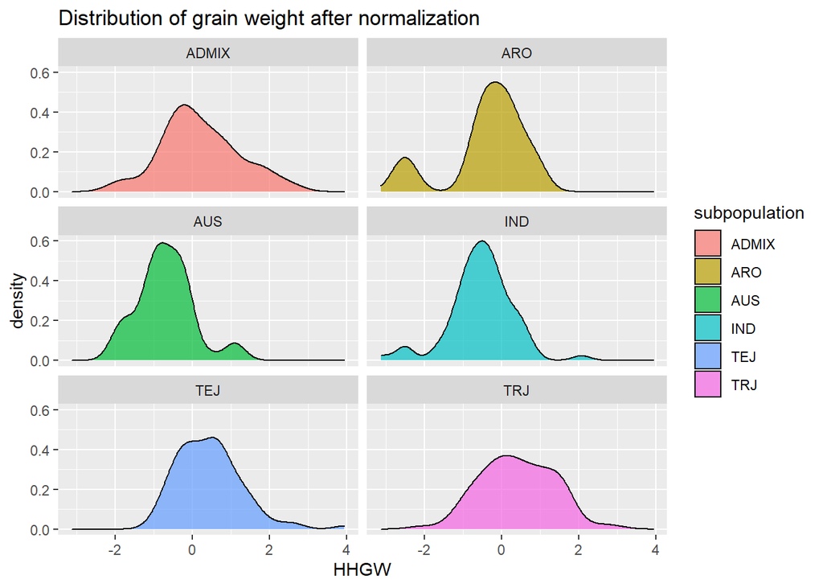

```r
# View distributions after data normalization}

norm1 %>%
  group_by(subpopulation) %>%
  summarise(subpopulation, HHGW) %>%
  ggplot(aes(x = HHGW, fill = subpopulation)) +
  geom_density(alpha = 0.7) +
  facet_wrap(~subpopulation, ncol = 2) +
  labs(title = "Distribution of grain weight after normalization")
```

**Principal Component Analysis**

```r
# I encountered an error downloading the ggbiplot package from GitHub so I copied the function code from the GitHub repo.

ggbiplot <- function(pcobj, choices = 1:2, scale = 1, pc.biplot = TRUE,
                     obs.scale = 1 - scale, var.scale = scale,
                     groups = NULL, ellipse = FALSE, ellipse.prob = 0.68,
                     labels = NULL, labels.size = 3, alpha = 1,
                     var.axes = TRUE,
                     circle = FALSE, circle.prob = 0.69,
                     varname.size = 3, varname.adjust = 1.5,
                     varname.abbrev = FALSE, ...)
{
  library(ggplot2)
  library(plyr)
  library(scales)
  library(grid)

  stopifnot(length(choices) == 2)

  # Recover the SVD
  if(inherits(pcobj, 'prcomp')){
    nobs.factor <- sqrt(nrow(pcobj$x) - 1)
    d <- pcobj$sdev
    u <- sweep(pcobj$x, 2, 1 / (d * nobs.factor), FUN = '*')
    v <- pcobj$rotation
  } else if(inherits(pcobj, 'princomp')) {
    nobs.factor <- sqrt(pcobj$n.obs)
    d <- pcobj$sdev
    u <- sweep(pcobj$scores, 2, 1 / (d * nobs.factor), FUN = '*')
    v <- pcobj$loadings
  } else if(inherits(pcobj, 'PCA')) {
    nobs.factor <- sqrt(nrow(pcobj$call$X))
    d <- unlist(sqrt(pcobj$eig)[1])
    u <- sweep(pcobj$ind$coord, 2, 1 / (d * nobs.factor), FUN = '*')
    v <- sweep(pcobj$var$coord,2,sqrt(pcobj$eig[1:ncol(pcobj$var$coord),1]),FUN="/")
  } else if(inherits(pcobj, "lda")) {
    nobs.factor <- sqrt(pcobj$N)
    d <- pcobj$svd
    u <- predict(pcobj)$x/nobs.factor
    v <- pcobj$scaling
    d.total <- sum(d^2)
  } else {
    stop('Expected a object of class prcomp, princomp, PCA, or lda')
  }

  # Scores
  choices <- pmin(choices, ncol(u))
  df.u <- as.data.frame(sweep(u[,choices], 2, d[choices]^obs.scale, FUN='*'))

  # Directions
  v <- sweep(v, 2, d^var.scale, FUN='*')
  df.v <- as.data.frame(v[, choices])

  names(df.u) <- c('xvar', 'yvar')
  names(df.v) <- names(df.u)

  if(pc.biplot) {
    df.u <- df.u * nobs.factor
  }

  # Scale the radius of the correlation circle so that it corresponds to
  # a data ellipse for the standardized PC scores
  r <- sqrt(qchisq(circle.prob, df = 2)) * prod(colMeans(df.u^2))^(1/4)

  # Scale directions
  v.scale <- rowSums(v^2)
  df.v <- r * df.v / sqrt(max(v.scale))

  # Change the labels for the axes
  if(obs.scale == 0) {
    u.axis.labs <- paste('standardized PC', choices, sep='')
  } else {
    u.axis.labs <- paste('PC', choices, sep='')
  }

  # Append the proportion of explained variance to the axis labels
  u.axis.labs <- paste(u.axis.labs,
                       sprintf('(%0.1f%% explained var.)',
                               100 * pcobj$sdev[choices]^2/sum(pcobj$sdev^2)))

  # Score Labels
  if(!is.null(labels)) {
    df.u$labels <- labels
  }

  # Grouping variable
  if(!is.null(groups)) {
    df.u$groups <- groups
  }

  # Variable Names
  if(varname.abbrev) {
    df.v$varname <- abbreviate(rownames(v))
  } else {
    df.v$varname <- rownames(v)
  }

  # Variables for text label placement
  df.v$angle <- with(df.v, (180/pi) * atan(yvar / xvar))
  df.v$hjust = with(df.v, (1 - varname.adjust * sign(xvar)) / 2)

  # Base plot
  g <- ggplot(data = df.u, aes(x = xvar, y = yvar)) +
    xlab(u.axis.labs[1]) + ylab(u.axis.labs[2]) + coord_equal()

  if(var.axes) {
    # Draw circle
    if(circle)
    {
      theta <- c(seq(-pi, pi, length = 50), seq(pi, -pi, length = 50))
      circle <- data.frame(xvar = r * cos(theta), yvar = r * sin(theta))
      g <- g + geom_path(data = circle, color = muted('white'),
                         size = 1/2, alpha = 1/3)
    }

    # Draw directions
    g <- g +
      geom_segment(data = df.v,
                   aes(x = 0, y = 0, xend = xvar, yend = yvar),
                   arrow = arrow(length = unit(1/2, 'picas')),
                   color = muted('red'))
  }

  # Draw either labels or points
  if(!is.null(df.u$labels)) {
    if(!is.null(df.u$groups)) {
      g <- g + geom_text(aes(label = labels, color = groups),
                         size = labels.size)
    } else {
      g <- g + geom_text(aes(label = labels), size = labels.size)
    }
  } else {
    if(!is.null(df.u$groups)) {
      g <- g + geom_point(aes(color = groups), alpha = alpha)
    } else {
      g <- g + geom_point(alpha = alpha)
    }
  }

  # Overlay a concentration ellipse if there are groups
  if(!is.null(df.u$groups) && ellipse) {
    theta <- c(seq(-pi, pi, length = 50), seq(pi, -pi, length = 50))
    circle <- cbind(cos(theta), sin(theta))

    ell <- ddply(df.u, 'groups', function(x) {
      if(nrow(x) <= 2) {
        return(NULL)
      }
      sigma <- var(cbind(x$xvar, x$yvar))
      mu <- c(mean(x$xvar), mean(x$yvar))
      ed <- sqrt(qchisq(ellipse.prob, df = 2))
      data.frame(sweep(circle %*% chol(sigma) * ed, 2, mu, FUN = '+'),
                 groups = x$groups[1])
    })
    names(ell)[1:2] <- c('xvar', 'yvar')
    g <- g + geom_path(data = ell, aes(color = groups, group = groups))
  }

  # Label the variable axes
  if(var.axes) {
    g <- g +
      geom_text(data = df.v,
                aes(label = varname, x = xvar, y = yvar,
                    angle = angle, hjust = hjust),
                color = 'darkred', size = varname.size)
  }
  # Change the name of the legend for groups
  # if(!is.null(groups)) {
  #   g <- g + scale_color_brewer(name = deparse(substitute(groups)),
  #                               palette = 'Dark2')
  # }

  # TODO: Add a second set of axes

  return(g)
}
```

```r
# compute PCA
rice.pca <- prcomp(norm1[,1:8], center = TRUE,scale. = TRUE)

# view pca summary
summary(rice.pca)
```

```
## Importance of components:
##                           PC1    PC2    PC3     PC4     PC5     PC6     PC7
## Standard deviation     1.7248 1.4214 1.1228 0.80165 0.66286 0.63019 0.43245
## Proportion of Variance 0.3719 0.2525 0.1576 0.08033 0.05492 0.04964 0.02338
## Cumulative Proportion  0.3719 0.6244 0.7820 0.86234 0.91726 0.96690 0.99028
##                            PC8
## Standard deviation     0.27883
## Proportion of Variance 0.00972
## Cumulative Proportion  1.00000
```

```r
# view pca structure
str(rice.pca)
```

```
## List of 5
##  $ sdev    : num [1:8] 1.725 1.421 1.123 0.802 0.663 ...
##  $ rotation: num [1:8, 1:8] -0.3657 -0.3812 0.3156 0.4178 0.0747 ...
##   ..- attr(*, "dimnames")=List of 2
##   .. ..$ : chr [1:8] "HHGW" "HGV" "PTH" "PNL" ...
##   .. ..$ : chr [1:8] "PC1" "PC2" "PC3" "PC4" ...
##  $ center  : Named num [1:8] 0.02193 0.01695 0.00642 0.01261 -0.02606 ...
##   ..- attr(*, "names")= chr [1:8] "HHGW" "HGV" "PTH" "PNL" ...
##  $ scale   : Named num [1:8] 0.989 0.995 0.984 0.994 0.954 ...
##   ..- attr(*, "names")= chr [1:8] "HHGW" "HGV" "PTH" "PNL" ...
##  $ x       : num [1:364, 1:8] -2.227 0.552 3.9 2.64 4.948 ...
##   ..- attr(*, "dimnames")=List of 2
##   .. ..$ : chr [1:364] "1" "2" "3" "4" ...
##   .. ..$ : chr [1:8] "PC1" "PC2" "PC3" "PC4" ...
##  - attr(*, "class")= chr "prcomp"
```

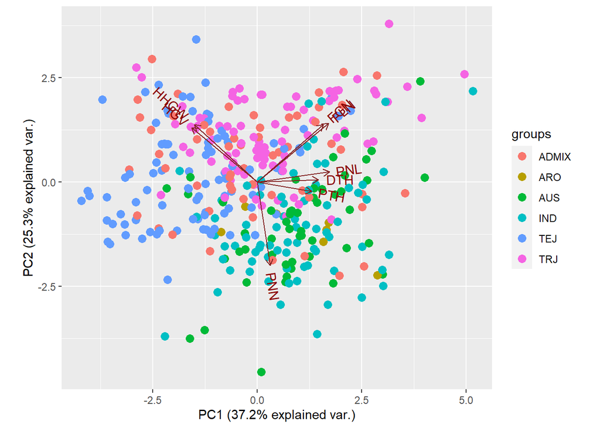

```r
P <- ggbiplot(rice.pca,
         obs.scale = 1,
         var.scale=1,
         ellipse=F,
         circle=F,
         varname.size=4,
         var.axes=T,
         groups=norm1$subpopulation, #no need for coloring, I'm making the points invisible
         alpha=0) #invisible points, I add them below
P$layers <- c(geom_point(aes(color=norm1$subpopulation), cex=3), P$layers) #add geom_point in a layer underneath (only way I have to change the size of the points in ggbiplot)

P
```

**Standardized Major Axis (SMA) regression**

**Relationship between Test weight and other agronomic traits**

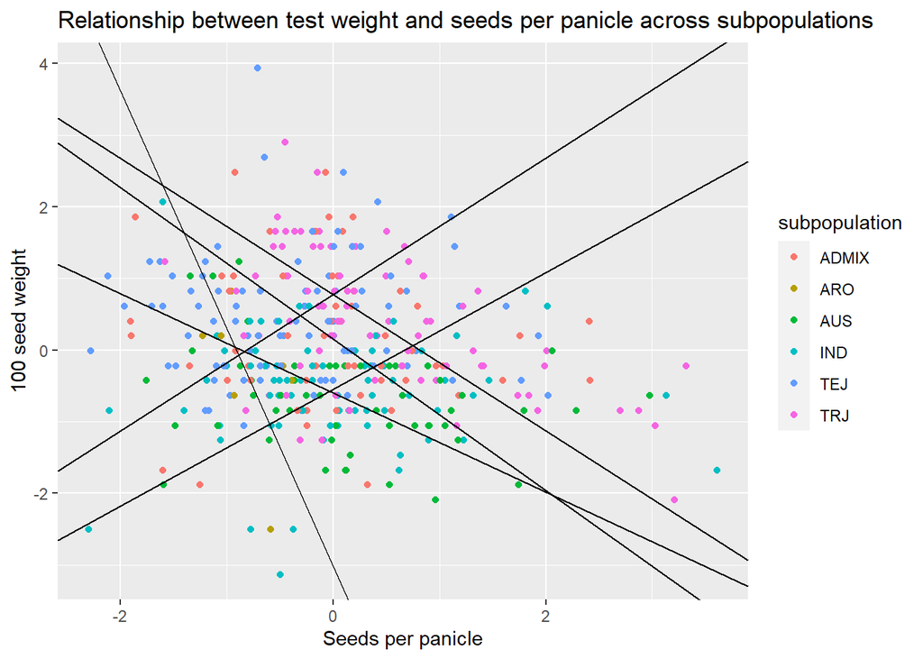

```r
# To plot relationship between seed per panicle and test weight across subpopulations

# assembly sma model coefficients into smaller objects using do.call and rbind
do.call(rbind, lapply(unique(norm1$subpopulation), function(x) {
  # make object for sma model and subset population
  obj <- sma(HHGW~FGN*subpopulation, data=subset(norm1, subpopulation == x), multcomp=TRUE,multcompmethod="adjusted")
  data.frame(subpopulation = x,
             intercept=obj$coef[[1]][1, 1],
             slope=obj$coef[[1]][2, 1])
})) -> fits

# plot relationship between seed per panicle and test weight across subpopulations
seeds_per_panicle <- ggplot(norm1) +
  geom_point(aes(x=FGN, y=HHGW, color=subpopulation)) +
  geom_abline(data=fits, aes(slope=slope, intercept=intercept)) +
  labs(x = "Seeds per panicle", y = "100 seed weight",
       title = "Relationship between test weight and seeds per panicle across subpopulations")

# visualize relationship
seeds_per_panicle
```

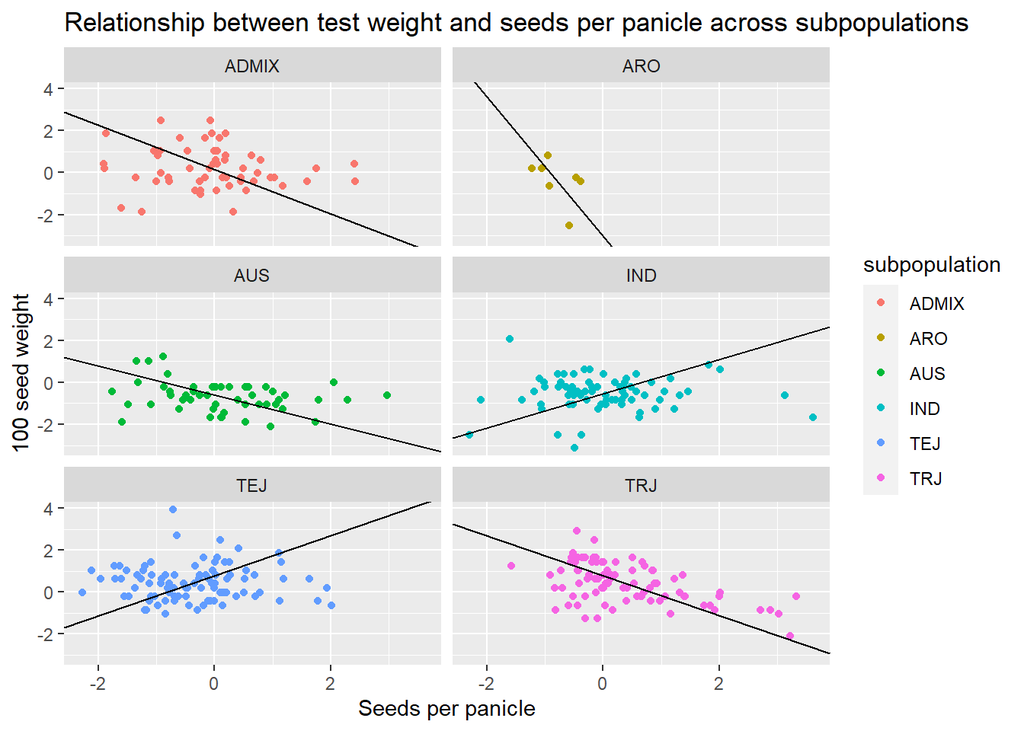

```r
# make a facet-wrap to view relationship across groups
seeds_per_panicle + facet_wrap(~subpopulation, ncol=2)
```

```r
# Perform sma analysis for seed per panicle across subpopulations
filgrnb_sma <-sma(HHGW~FGN*subpopulation, data=norm1,multcomp=TRUE,multcompmethod="adjusted")

# view group summary
filgrnb_sma$groupsummary %>%
  kbl(format = 'html') %>%
  kable_paper() %>%
  scroll_box(width = "700px",
             height = "350px")       # Using KableExtra table formatting
```

| group | n | r2 | pval | Slope | Slope_lowCI | Slope_highCI | Int | Int_lowCI | Int_highCI | Slope_test | Slope_test_p | Elev_test | Elev_test_p |
| --- | --- | --- | --- | --- | --- | --- | --- | --- | --- | --- | --- | --- | --- |
| ADMIX | 56 | 0.0121245 | 0.4191634 | -1.0579973 | -1.3831041 | -0.8093088 | 0.1553618 | -0.2030996 | 0.5138232 | NA | NA | NA | NA |
| ARO | 7 | 0.2221491 | 0.2856813 | -3.3189881 | -8.0916075 | -1.3613713 | -3.0181351 | -5.9428513 | -0.0934189 | NA | NA | NA | NA |
| AUS | 51 | 0.0722018 | 0.0565743 | -0.6931603 | -0.9108492 | -0.5274981 | -0.5983793 | -0.8477217 | -0.3490369 | NA | NA | NA | NA |
| IND | 73 | 0.0003167 | 0.8812093 | 0.8160154 | 0.6454752 | 1.0316138 | -0.5489209 | -0.8172319 | -0.2806098 | NA | NA | NA | NA |
| TEJ | 92 | 0.0000000 | 0.9992490 | 0.9523719 | 0.7735907 | 1.1724705 | 0.7747140 | 0.5149058 | 1.0345222 | NA | NA | NA | NA |
| TRJ | 85 | 0.2515723 | 0.0000010 | -0.9518213 | -1.1484191 | -0.7888790 | 0.7758076 | 0.5609367 | 0.9906784 | NA | NA | NA | NA |

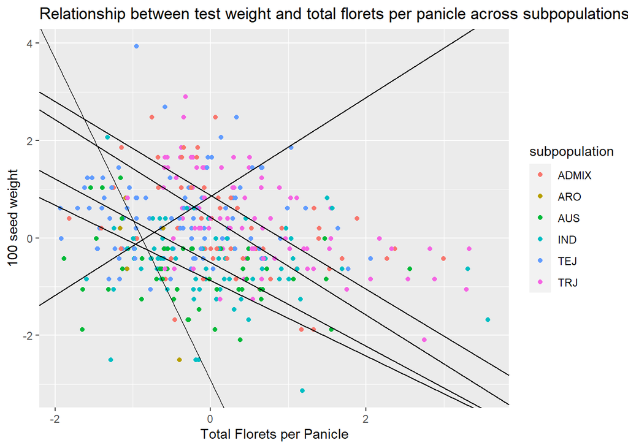

```r
#------------------------------------------------------------------------------

# To plot the relationship between Total Florets per panicle and 100 seed weight

# assembly sma model coefficients into smaller objects using do.call and rbind
do.call(rbind, lapply(unique(norm1$subpopulation), function(x) {
  # make object for sma model and subset population
  obj <- sma(HHGW~FLN*subpopulation, data=subset(norm1, subpopulation == x), multcomp=TRUE,multcompmethod="adjusted")
  data.frame(subpopulation = x,
             intercept=obj$coef[[1]][1, 1],
             slope=obj$coef[[1]][2, 1])
})) -> fits

# plot relationship between seed per panicle and test weight across subpopulations
florets_per_panicle <- ggplot(norm1) +
  geom_point(aes(x=FLN, y=HHGW, color=subpopulation)) +
  geom_abline(data=fits, aes(slope=slope, intercept=intercept)) +
  labs(x = "Total Florets per Panicle", y = "100 seed weight",
       title = "Relationship between test weight and total florets per panicle across subpopulations")

# visualize relationship
florets_per_panicle
```

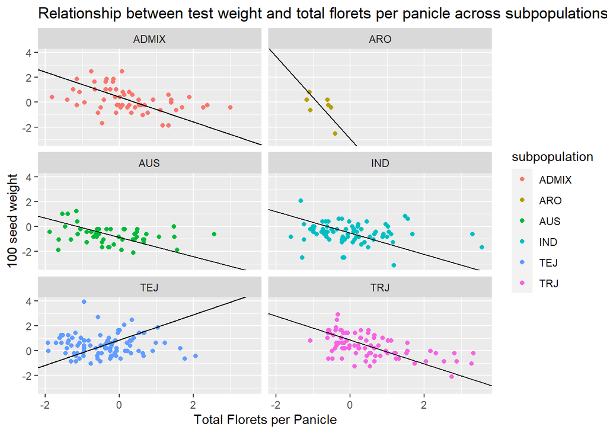

```r
# make a facet-wrap to view relationship across groups
florets_per_panicle + facet_wrap(~subpopulation, ncol=2)
```

```r
# Perform sma analysis for Total Florets per panicle across subpopulations
flnbppn_sma <-sma(HHGW~FLN*subpopulation, data=norm1,multcomp=TRUE,multcompmethod="adjusted")

# view group summary
flnbppn_sma$groupsummary %>%
  kbl(format = 'html') %>%
  kable_paper() %>%
  scroll_box(width = "700px",
             height = "350px")        # Using KableExtra table formatting
```

| group | n | r2 | pval | Slope | Slope_lowCI | Slope_highCI | Int | Int_lowCI | Int_highCI | Slope_test | Slope_test_p | Elev_test | Elev_test_p |
| --- | --- | --- | --- | --- | --- | --- | --- | --- | --- | --- | --- | --- | --- |
| ADMIX | 56 | 0.1613282 | 0.0021530 | -1.0019881 | -1.2831417 | -0.7824390 | 0.4253753 | 0.1263962 | 0.7243544 | NA | NA | NA | NA |
| ARO | 7 | 0.3560280 | 0.1572758 | -3.3027580 | -7.5404121 | -1.4466332 | -2.9293795 | -5.4986269 | -0.3601320 | NA | NA | NA | NA |
| AUS | 51 | 0.0767219 | 0.0490988 | -0.7737894 | -1.0161392 | -0.5892401 | -0.8708629 | -1.1211628 | -0.6205630 | NA | NA | NA | NA |
| IND | 73 | 0.0280656 | 0.1565744 | -0.8576659 | -1.0807839 | -0.6806086 | -0.5036280 | -0.7507534 | -0.2565026 | NA | NA | NA | NA |
| TEJ | 92 | 0.0000873 | 0.9295503 | 1.0138130 | 0.8235053 | 1.2480998 | 0.8539348 | 0.5901924 | 1.1176772 | NA | NA | NA | NA |
| TRJ | 85 | 0.3162021 | 0.0000000 | -0.9617684 | -1.1509440 | -0.8036867 | 0.8723962 | 0.6641858 | 1.0806066 | NA | NA | NA | NA |

[figure not shown]

```r
#------------------------------------------------------------------------------


# To estimate the relationship between panicles per plant and 100 seed weight

# assembly sma model coefficients into smaller objects using do.call and rbind
do.call(rbind, lapply(unique(norm1$subpopulation), function(x) {
  # make object for sma model and subset population
  obj <- sma(HHGW~FLN*subpopulation, data=subset(norm1, subpopulation == x), multcomp=TRUE,multcompmethod="adjusted")
  data.frame(subpopulation = x,
             intercept=obj$coef[[1]][1, 1],
             slope=obj$coef[[1]][2, 1])
})) -> fits

# plot relationship between panicles per plant and test weight across subpopulations
panicles_per_plant <- ggplot(norm1) +
  geom_point(aes(x=PNN, y=HHGW, color=subpopulation)) +
  geom_abline(data=fits, aes(slope=slope, intercept=intercept)) +
  labs(x = "Panicle per plant", y = "100 seed weight",
       title = "Relationship between test weight and panicles per plant across subpopulations")

# visualize relationship
panicles_per_plant
```

[figure not shown]

```r
# make a facet-wrap to view relationship across groups
panicles_per_plant + facet_wrap(~subpopulation, ncol=2)
```

```r
# Perform sma analysis for panicles per plant across subpopulations
pnnb_sma <-sma(HHGW~PNN*subpopulation, data=norm1,multcomp=TRUE,multcompmethod="adjusted")

# view group summary
pnnb_sma$groupsummary %>%
  kbl(format = 'html') %>%
  kable_paper() %>%
  scroll_box(width = "700px",
             height = "350px")            # Using KableExtra table formatting
```

| group | n | r2 | pval | Slope | Slope_lowCI | Slope_highCI | Int | Int_lowCI | Int_highCI | Slope_test | Slope_test_p | Elev_test | Elev_test_p |
| --- | --- | --- | --- | --- | --- | --- | --- | --- | --- | --- | --- | --- | --- |
| ADMIX | 56 | 0.1381634 | 0.0047924 | -1.3066327 | -1.678839 | -1.0169464 | -0.2327722 | -0.5533354 | 0.0877910 | NA | NA | NA | NA |
| ARO | 7 | 0.0148219 | 0.7948473 | 3.1650317 | 1.190632 | 8.4135364 | -0.3755597 | -1.8688436 | 1.1177243 | NA | NA | NA | NA |
| AUS | 51 | 0.0877770 | 0.0347723 | -0.8982791 | -1.177736 | -0.6851323 | -0.1998707 | -0.4796015 | 0.0798600 | NA | NA | NA | NA |
| IND | 73 | 0.0212668 | 0.2182957 | -1.0111003 | -1.275145 | -0.8017317 | 0.5352962 | 0.1808400 | 0.8897523 | NA | NA | NA | NA |
| TEJ | 92 | 0.0681682 | 0.0119433 | -1.4595375 | -1.784107 | -1.1940148 | 0.1097310 | -0.1148818 | 0.3343438 | NA | NA | NA | NA |
| TRJ | 85 | 0.0135029 | 0.2895732 | -2.6793730 | -3.322629 | -2.1606505 | -2.0072094 | -2.5961890 | -1.4182299 | NA | NA | NA | NA |

[figure not shown]

```r
#------------------------------------------------------------------------------

# To estimate the relationship between plant height and 100 seed weight

# assembly sma model coefficients into smaller objects using do.call and rbind
do.call(rbind, lapply(unique(norm1$subpopulation), function(x) {
  # make object for sma model and subset population
  obj <- sma(HHGW~PTH*subpopulation, data=subset(norm1, subpopulation == x), multcomp=TRUE,multcompmethod="adjusted")
  data.frame(subpopulation = x,
             intercept=obj$coef[[1]][1, 1],
             slope=obj$coef[[1]][2, 1])
})) -> fits

# plot relationship between plant height and test weight across subpopulations
plant_height <- ggplot(norm1) +
  geom_point(aes(x=PTH, y=HHGW, color=subpopulation)) +
  geom_abline(data=fits, aes(slope=slope, intercept=intercept)) +
  labs(x = "Plant height", y = "100 seed weight",
       title = "Relationship between test weight and plant height across regions")

# visualize relationship
plant_height
```

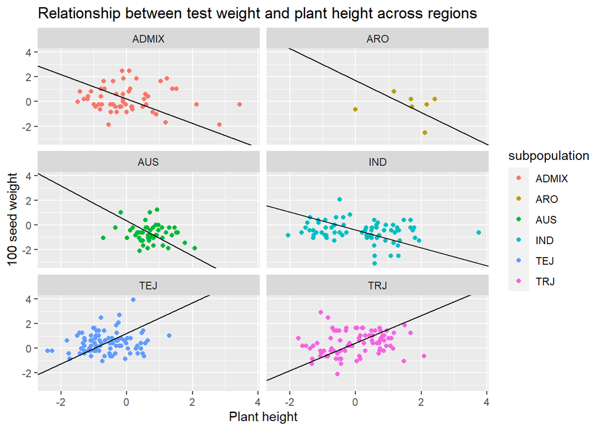

```r
# make a facet-wrap to view relationship across groups
plant_height + facet_wrap(~subpopulation, ncol=2)
```

```r
# Perform sma analysis for panicles per plant across subpopulations
ptht_sma <-sma(HHGW~PTH*subpopulation, data=norm1,multcomp=TRUE,multcompmethod="adjusted")

# view group summary
ptht_sma$groupsummary %>%
  kbl(format = 'html') %>%
  kable_paper() %>%
  scroll_box(width = "700px",
             height = "350px")            # Using KableExtra table formatting
```

| group | n | r2 | pval | Slope | Slope_lowCI | Slope_highCI | Int | Int_lowCI | Int_highCI | Slope_test | Slope_test_p | Elev_test | Elev_test_p |
| --- | --- | --- | --- | --- | --- | --- | --- | --- | --- | --- | --- | --- | --- |
| ADMIX | 56 | 0.0118435 | 0.4246377 | -0.9903552 | -1.2947248 | -0.7575381 | 0.2082924 | -0.1502028 | 0.5667876 | NA | NA | NA | NA |
| ARO | 7 | 0.0128631 | 0.8086956 | -1.2907307 | -3.4336862 | -0.4851887 | 1.7019968 | -1.0996128 | 4.5036064 | NA | NA | NA | NA |
| AUS | 51 | 0.0263307 | 0.2552656 | -1.4129056 | -1.8687461 | -1.0682576 | 0.3222571 | -0.0715528 | 0.7160670 | NA | NA | NA | NA |
| IND | 73 | 0.0482383 | 0.0618992 | -0.7246572 | -0.9110112 | -0.5764232 | -0.3988271 | -0.6400974 | -0.1575568 | NA | NA | NA | NA |
| TEJ | 92 | 0.0282577 | 0.1092141 | 1.2331440 | 1.0045823 | 1.5137078 | 1.2298064 | 0.9489479 | 1.5106649 | NA | NA | NA | NA |
| TRJ | 85 | 0.0402848 | 0.0654966 | 1.1154818 | 0.9021361 | 1.3792814 | 0.4182288 | 0.1609324 | 0.6755252 | NA | NA | NA | NA |

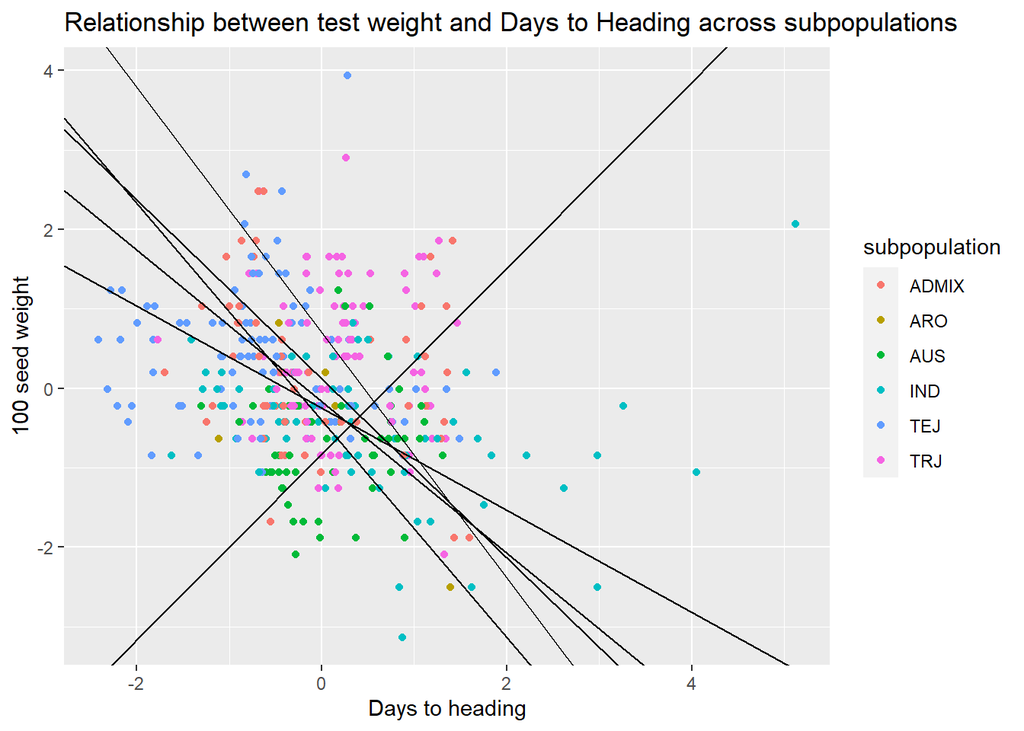

```r
#------------------------------------------------------------------------------


# To estimate the relationship between days to heading and 100 seed weight

# assembly sma model coefficients into smaller objects using do.call and rbind
do.call(rbind, lapply(unique(norm1$subpopulation), function(x) {
  # make object for sma model and subset population
  obj <- sma(HHGW~DTH*subpopulation, data=subset(norm1, subpopulation == x), multcomp=TRUE,multcompmethod="adjusted")
  data.frame(subpopulation = x,
             intercept=obj$coef[[1]][1, 1],
             slope=obj$coef[[1]][2, 1])
})) -> fits

# plot relationship between days to heading and test weight across subpopulations
days_to_heading <- ggplot(norm1) +
  geom_point(aes(x=DTH, y=HHGW, color=subpopulation)) +
  geom_abline(data=fits, aes(slope=slope, intercept=intercept)) +
  labs(x = "Days to heading", y = "100 seed weight",
       title = "Relationship between test weight and Days to Heading across subpopulations")

# visualize relationship
days_to_heading
```

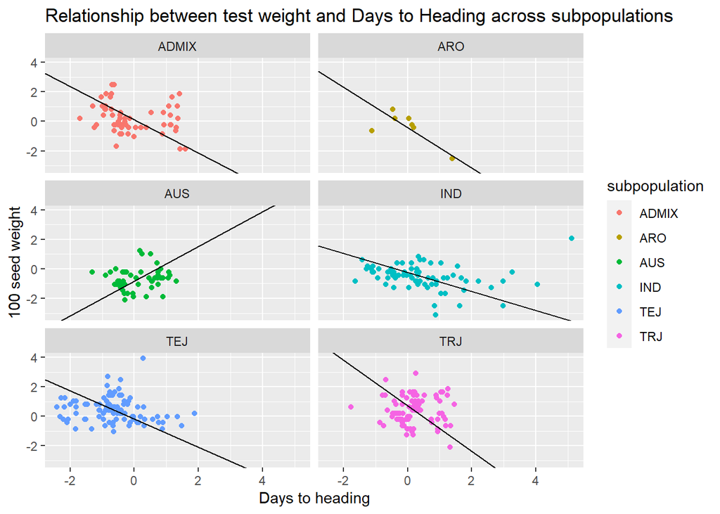

```r
# make a facet-wrap to view relationship across groups
days_to_heading + facet_wrap(~subpopulation, ncol=2)
```

```r
# Perform sma analysis for days to heading across subpopulations
dthd_sma <-sma(HHGW~DTH*subpopulation, data=norm1,multcomp=TRUE,multcompmethod="adjusted")

# view group summary
dthd_sma$groupsummary %>%
  kbl(format = 'html') %>%
  kable_paper() %>%
  scroll_box(width = "700px",
             height = "350px")            # Using KableExtra table formatting
```

| group | n | r2 | pval | Slope | Slope_lowCI | Slope_highCI | Int | Int_lowCI | Int_highCI | Slope_test | Slope_test_p | Elev_test | Elev_test_p |
| --- | --- | --- | --- | --- | --- | --- | --- | --- | --- | --- | --- | --- | --- |
| ADMIX | 56 | 0.0570007 | 0.0763853 | -1.1270561 | -1.4645429 | -0.8673391 | 0.1121810 | -0.2200131 | 0.4443752 | NA | NA | NA | NA |
| ARO | 7 | 0.4841719 | 0.0825206 | -1.3669631 | -2.9013274 | -0.6440459 | -0.4074222 | -1.2867789 | 0.4719346 | NA | NA | NA | NA |
| AUS | 51 | 0.0192425 | 0.3316554 | 1.1706593 | 0.8842261 | 1.5498786 | -0.8271417 | -1.0979854 | -0.5562980 | NA | NA | NA | NA |
| IND | 73 | 0.0295793 | 0.1456815 | -0.6419890 | -0.8088564 | -0.5095464 | -0.2516907 | -0.5068615 | 0.0034801 | NA | NA | NA | NA |
| TEJ | 92 | 0.0186075 | 0.1947779 | -0.9552551 | -1.1737686 | -0.7774210 | -0.1698103 | -0.4337191 | 0.0940985 | NA | NA | NA | NA |
| TRJ | 85 | 0.0007544 | 0.8029571 | -1.5460831 | -1.9198803 | -1.2450635 | 0.7033897 | 0.4122409 | 0.9945385 | NA | NA | NA | NA |

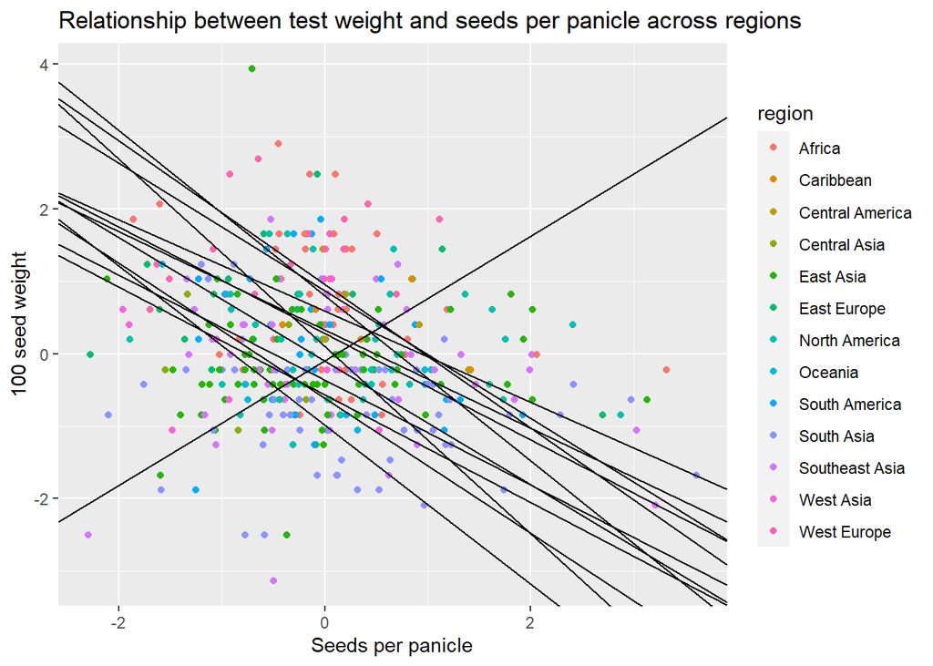

```r
# To relationship between seed per panicle and test weight across regions

# assembly sma model coefficients into smaller objects using do.call and rbind
do.call(rbind, lapply(unique(norm1$region), function(x) {
  # make object for sma model and subset population
  obj <- sma(HHGW~FGN*region, data=subset(norm1, region == x), multcomp=TRUE,multcompmethod="adjusted")
  data.frame(region = x,
             intercept=obj$coef[[1]][1, 1],
             slope=obj$coef[[1]][2, 1])
})) -> fits

# plot relationship between seed per panicle and test weight across regions
seeds_per_panicle <- ggplot(norm1) +
  geom_point(aes(x=FGN, y=HHGW, color=region)) +
  geom_abline(data=fits, aes(slope=slope, intercept=intercept)) +
  labs(x = "Seeds per panicle", y = "100 seed weight",
       title = "Relationship between test weight and seeds per panicle across regions")

# visualize relationship
seeds_per_panicle
```

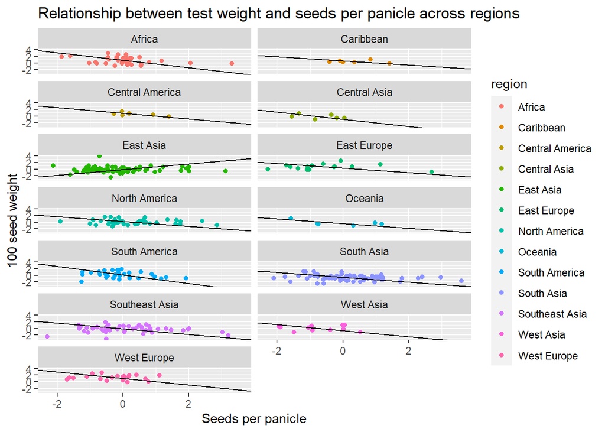

```r
# make a facet-wrap to view relationship across groups
seeds_per_panicle + facet_wrap(~region, ncol=2)
```

```r
# Perform sma analysis for seed per panicle across regions
filgrnb1_sma <-sma(HHGW~FGN*region, data=norm1,multcomp=TRUE,multcompmethod="adjusted")

# view group summary
filgrnb1_sma$groupsummary %>%
  kbl(format = 'html') %>%
  kable_paper() %>%
  scroll_box(width = "700px",
             height = "350px")      # Using KableExtra table formatting
```

| group | n | r2 | pval | Slope | Slope_lowCI | Slope_highCI | Int | Int_lowCI | Int_highCI | Slope_test | Slope_test_p | Elev_test | Elev_test_p |
| --- | --- | --- | --- | --- | --- | --- | --- | --- | --- | --- | --- | --- | --- |
| Africa | 37 | 0.1038062 | 0.0518053 | -1.1395415 | -1.5683439 | -0.8279783 | 0.7981303 | 0.4009233 | 1.1953373 | NA | NA | NA | NA |
| Caribbean | 6 | 0.0685432 | 0.6162613 | -0.6306579 | -1.8993192 | -0.2094063 | 0.5911244 | -0.1275153 | 1.3097641 | NA | NA | NA | NA |
| Central America | 6 | 0.4047575 | 0.1744462 | -0.8800483 | -2.2321099 | -0.3469744 | 0.8680227 | 0.1612131 | 1.5748324 | NA | NA | NA | NA |
| Central Asia | 6 | 0.1373502 | 0.4695396 | -1.0977920 | -3.2067302 | -0.3758181 | -0.9904780 | -2.4043457 | 0.4233898 | NA | NA | NA | NA |
| East Asia | 74 | 0.0007424 | 0.8177540 | 0.8618698 | 0.6829122 | 1.0877233 | -0.0957317 | -0.3602370 | 0.1687735 | NA | NA | NA | NA |
| East Europe | 15 | 0.0045454 | 0.8113138 | -0.6786493 | -1.1963794 | -0.3849656 | 0.3255896 | -0.3758267 | 1.0270060 | NA | NA | NA | NA |
| North America | 43 | 0.0158674 | 0.4208852 | -0.7349767 | -1.0000780 | -0.5401487 | 0.2770053 | -0.0168251 | 0.5708357 | NA | NA | NA | NA |
| Oceania | 6 | 0.3608716 | 0.2073036 | -0.7256853 | -1.8894745 | -0.2787120 | -0.3652131 | -1.2710989 | 0.5406727 | NA | NA | NA | NA |
| South America | 30 | 0.0610612 | 0.1880170 | -1.2935255 | -1.8667460 | -0.8963234 | 0.0973052 | -0.3656056 | 0.5602159 | NA | NA | NA | NA |
| South Asia | 63 | 0.0494662 | 0.0797754 | -0.7445339 | -0.9532235 | -0.5815328 | -0.5703187 | -0.8336862 | -0.3069512 | NA | NA | NA | NA |
| Southeast Asia | 46 | 0.0105168 | 0.4976533 | -0.8542723 | -1.1506184 | -0.6342513 | -0.1038009 | -0.4983028 | 0.2907009 | NA | NA | NA | NA |
| West Asia | 11 | 0.0089617 | 0.7818864 | -0.9335995 | -1.8681939 | -0.4665511 | -0.6187488 | -1.5346333 | 0.2971357 | NA | NA | NA | NA |
| West Europe | 21 | 0.0023361 | 0.8351923 | -0.9910938 | -1.5745282 | -0.6238484 | 0.9547820 | 0.4382989 | 1.4712650 | NA | NA | NA | NA |

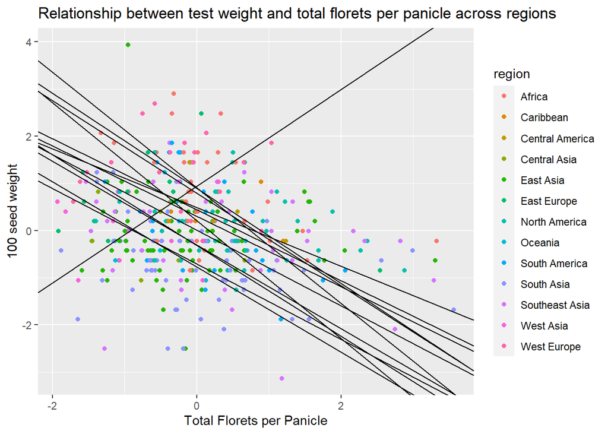

```r
#------------------------------------------------------------------------------

# To estimate the relationship between Total Florets per panicle and 100 seed weight

# assembly sma model coefficients into smaller objects using do.call and rbind
do.call(rbind, lapply(unique(norm1$region), function(x) {
  # make object for sma model and subset population
  obj <- sma(HHGW~FLN*region, data=subset(norm1, region == x), multcomp=TRUE,multcompmethod="adjusted")
  data.frame(region= x,
             intercept=obj$coef[[1]][1, 1],
             slope=obj$coef[[1]][2, 1])
})) -> fits

# plot relationship between seed per panicle and test weight across regions
florets_per_panicle <- ggplot(norm1) +
  geom_point(aes(x=FLN, y=HHGW, color=region)) +
  geom_abline(data=fits, aes(slope=slope, intercept=intercept)) +
  labs(x = "Total Florets per Panicle", y = "100 seed weight",
       title = "Relationship between test weight and total florets per panicle across regions")

# visualize relationship
florets_per_panicle
```

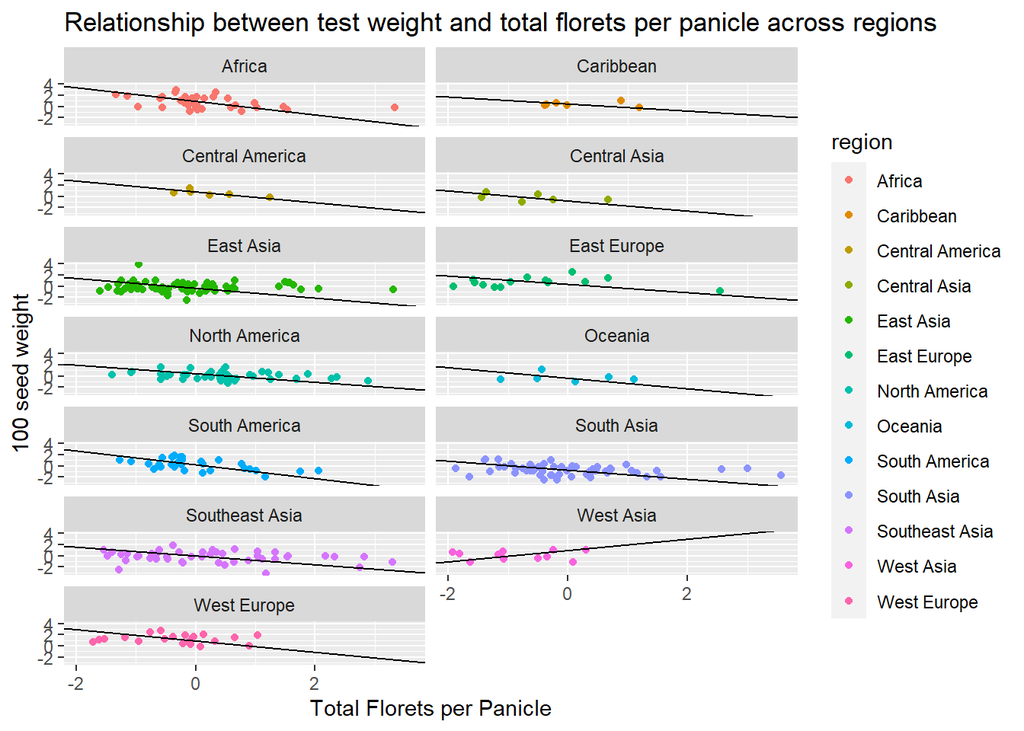

```r
# make a facet-wrap to view relationship across groups
florets_per_panicle + facet_wrap(~region, ncol=2)
```

```r
# Perform sma analysis for Total Florets per panicle across regions
flnbppn1_sma <-sma(HHGW~FLN*region, data=norm1,multcomp=TRUE,multcompmethod="adjusted")

# view group summary
flnbppn1_sma$groupsummary %>%
  kbl(format = 'html') %>%
  kable_paper() %>%
  scroll_box(width = "700px",
             height = "350px")       # Using KableExtra table formatting
```

| group | n | r2 | pval | Slope | Slope_lowCI | Slope_highCI | Int | Int_lowCI | Int_highCI | Slope_test | Slope_test_p | Elev_test | Elev_test_p |
| --- | --- | --- | --- | --- | --- | --- | --- | --- | --- | --- | --- | --- | --- |
| Africa | 37 | 0.1824934 | 0.0083630 | -1.2247427 | -1.6623304 | -0.9023444 | 0.9025426 | 0.5346671 | 1.2704181 | NA | NA | NA | NA |
| Caribbean | 6 | 0.0058945 | 0.8850630 | -0.6217080 | -1.9221328 | -0.2010896 | 0.4849523 | -0.2637442 | 1.2336489 | NA | NA | NA | NA |
| Central America | 6 | 0.5675139 | 0.0837613 | -0.9795673 | -2.2206821 | -0.4320979 | 0.7868129 | 0.2336541 | 1.3399717 | NA | NA | NA | NA |
| Central Asia | 6 | 0.2078680 | 0.3634980 | -0.9024660 | -2.5495213 | -0.3194501 | -0.7732753 | -1.9320294 | 0.3854787 | NA | NA | NA | NA |
| East Asia | 74 | 0.0000042 | 0.9862292 | -0.8872140 | -1.1198035 | -0.7029346 | -0.3062358 | -0.5754577 | -0.0370139 | NA | NA | NA | NA |
| East Europe | 15 | 0.0024563 | 0.8607635 | -0.7441415 | -1.3125404 | -0.4218892 | 0.2996701 | -0.4128345 | 1.0121747 | NA | NA | NA | NA |
| North America | 43 | 0.0952134 | 0.0440929 | -0.7525207 | -1.0114193 | -0.5598938 | 0.4403637 | 0.1625446 | 0.7181829 | NA | NA | NA | NA |
| Oceania | 6 | 0.0381806 | 0.7106325 | -0.9618998 | -2.9344850 | -0.3153028 | -0.3175809 | -1.5986496 | 0.9634879 | NA | NA | NA | NA |
| South America | 30 | 0.2966206 | 0.0018599 | -1.2485895 | -1.7181157 | -0.9073753 | 0.2048406 | -0.1542327 | 0.5639140 | NA | NA | NA | NA |
| South Asia | 63 | 0.0774085 | 0.0272509 | -0.7995030 | -1.0199343 | -0.6267120 | -0.7127386 | -0.9639363 | -0.4615409 | NA | NA | NA | NA |
| Southeast Asia | 46 | 0.0531385 | 0.1232532 | -0.7999274 | -1.0706494 | -0.5976596 | 0.0055228 | -0.3641482 | 0.3751938 | NA | NA | NA | NA |
| West Asia | 11 | 0.0015596 | 0.9082219 | 1.0253296 | 0.5112472 | 2.0563454 | 0.9416803 | -0.0834793 | 1.9668400 | NA | NA | NA | NA |
| West Europe | 21 | 0.0047711 | 0.7660808 | -1.0065084 | -1.5981729 | -0.6338858 | 0.8928619 | 0.3737050 | 1.4120189 | NA | NA | NA | NA |

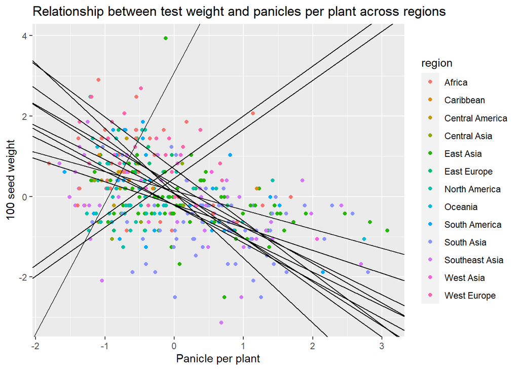

```r
#------------------------------------------------------------------------------

# To estimate the relationship between panicles per plant and 100 seed weight

# assembly sma model coefficients into smaller objects using do.call and rbind
do.call(rbind, lapply(unique(norm1$region), function(x) {
  # make object for sma model and subset population
  obj <- sma(HHGW~PNN*region, data=subset(norm1, region == x), multcomp=TRUE,multcompmethod="adjusted")
  data.frame(region = x,
             intercept=obj$coef[[1]][1, 1],
             slope=obj$coef[[1]][2, 1])
})) -> fits

# plot relationship between panicles per plant and test weight across regions
panicles_per_plant <- ggplot(norm1) +
  geom_point(aes(x=PNN, y=HHGW, color=region)) +
  geom_abline(data=fits, aes(slope=slope, intercept=intercept)) +
  labs(x = "Panicle per plant", y = "100 seed weight",
       title = "Relationship between test weight and panicles per plant across regions")

# visualize relationship
panicles_per_plant
```

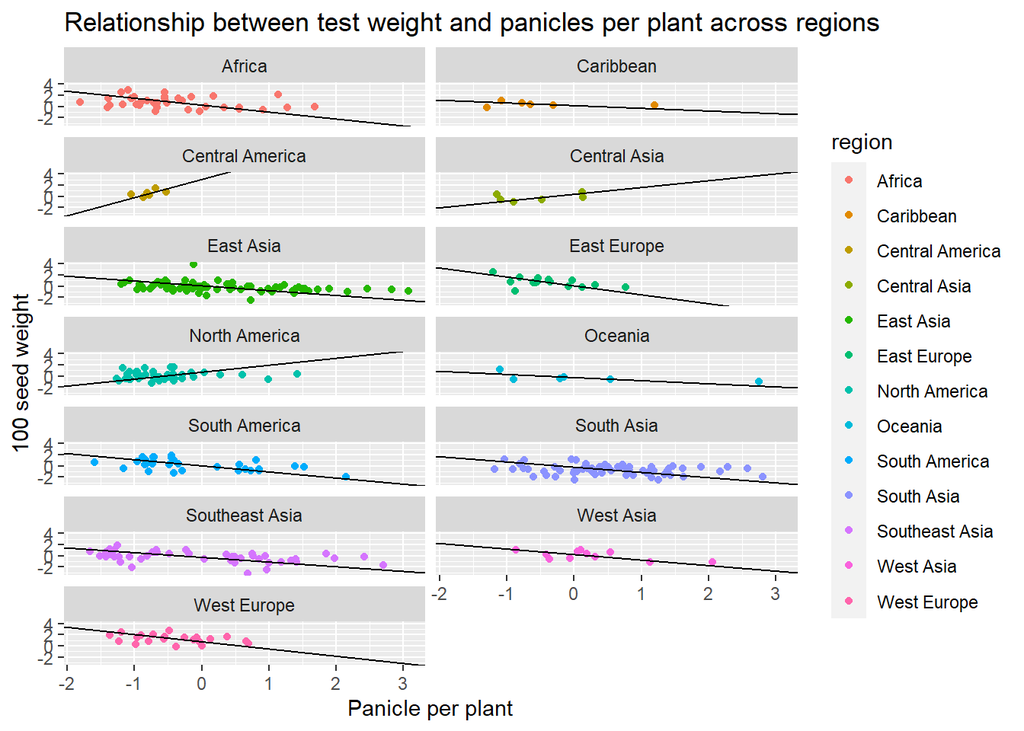

```r
# make a facet-wrap to view relationship across regions
panicles_per_plant + facet_wrap(~region, ncol=2)
```

```r
# Perform sma analysis for panicles per plant across regions
pnnb1_sma <-sma(HHGW~PNN*region, data=norm1,multcomp=TRUE,multcompmethod="adjusted")

# view group summary
pnnb1_sma$groupsummary %>%
  kbl(format = 'html') %>%
  kable_paper() %>%
  scroll_box(width = "700px",
             height = "350px")          # Using KableExtra table formatting
```

| group | n | r2 | pval | Slope | Slope_lowCI | Slope_highCI | Int | Int_lowCI | Int_highCI | Slope_test | Slope_test_p | Elev_test | Elev_test_p |
| --- | --- | --- | --- | --- | --- | --- | --- | --- | --- | --- | --- | --- | --- |
| Africa | 37 | 0.0982540 | 0.0588716 | -1.2364862 | -1.7033950 | -0.8975593 | 0.2075433 | -0.2294960 | 0.6445827 | NA | NA | NA | NA |
| Caribbean | 6 | 0.0276460 | 0.7528919 | -0.4763870 | -1.4597221 | -0.1554711 | 0.1371494 | -0.6263329 | 0.9006317 | NA | NA | NA | NA |
| Central America | 6 | 0.2714903 | 0.2891587 | 3.2463278 | 1.1868026 | 8.8798628 | 3.0949157 | -0.0113749 | 6.2012063 | NA | NA | NA | NA |
| Central Asia | 6 | 0.1525534 | 0.4439209 | 1.2164528 | 0.4193714 | 3.5285131 | 0.4598387 | -0.8589333 | 1.7786107 | NA | NA | NA | NA |
| East Asia | 74 | 0.1473644 | 0.0007344 | -0.8401930 | -1.0420001 | -0.6774705 | 0.0796029 | -0.1373261 | 0.2965319 | NA | NA | NA | NA |
| East Europe | 15 | 0.2781364 | 0.0433516 | -1.6136370 | -2.6321650 | -0.9892330 | 0.0772868 | -0.4913607 | 0.6459344 | NA | NA | NA | NA |
| North America | 43 | 0.0003400 | 0.9065756 | 1.2394581 | 0.9087676 | 1.6904832 | 0.7702358 | 0.3952447 | 1.1452269 | NA | NA | NA | NA |
| Oceania | 6 | 0.4271472 | 0.1592367 | -0.5701319 | -1.4260224 | -0.2279420 | -0.2029340 | -1.0481804 | 0.6423123 | NA | NA | NA | NA |
| South America | 30 | 0.2715049 | 0.0031527 | -1.0937199 | -1.5132481 | -0.7905004 | 0.0680064 | -0.3023325 | 0.4383453 | NA | NA | NA | NA |
| South Asia | 63 | 0.0551354 | 0.0639668 | -0.9367392 | -1.1984358 | -0.7321880 | -0.2173011 | -0.5045463 | 0.0699441 | NA | NA | NA | NA |
| Southeast Asia | 46 | 0.1993628 | 0.0018681 | -0.8358917 | -1.0934764 | -0.6389849 | -0.2066121 | -0.5153668 | 0.1021427 | NA | NA | NA | NA |
| West Asia | 11 | 0.3602667 | 0.0508948 | -0.9851505 | -1.7446157 | -0.5562953 | 0.3023817 | -0.2227482 | 0.8275117 | NA | NA | NA | NA |
| West Europe | 21 | 0.1134283 | 0.1354687 | -1.2945534 | -2.0060117 | -0.8354231 | 0.6785127 | 0.1948718 | 1.1621536 | NA | NA | NA | NA |